# Analysis of Airport Centrality and Domestic Flight Costs

Author: Pranav Rane

### Introduction

In this project, I will take you through the data science lifecycle - a series of tasks to create interpretations about the world around us. This includes collecting, tidying, exploring, and modeling data. Specifically, I will be analyzing the connections and the costs associated in domestic flights. However, the general steps in the data science lifecycle can be applied to understand a variety of relationships from any of the vast data available on the internet.

Over the decades, air travel in the United States has become a very quick, safe, and sometimes even cheap method of transportation for medium to long distance trips. However, besides offering transportation services to consumers, airports also bring countries, states, and even communities [together](https://www.stantec.com/en/ideas/beyond-the-terminals-how-airports-are-helping-strengthen-communities-and-promote-culture).

As many people, programs, and political groups strive for, cultural diversification is a key goal to foster inclusion between geographically separated groups. Cities that have access to well-connected airports have cultural diversity at their footstep. For these cities, it may be in their interest to invest in diversity, equity, and inclusion [policies](https://govlaunch.com/stories/6-ways-cities-can-promote-diversity-inclusion-and-equity) for their communities.

But how do we identify these cities? Which cities have access to popular airports? Determining this will be the main goal of the first part of this project.

To identify popular airports, we can use statistics that utilize the number of connections going in and out of a particular airport. However, what if a flight into a particular airport is very expensive? Surely that may reduce the economic diversity of the passengers that end up in a particular city. So, how can we make expensive destinations more accessible? Is there anyway we can reduce the cost of transportation to reach a particular city? This will be the main goal of the second part of this project.

#### Imports

Let's install the Python libraries we will need.

```python
import pandas as pd
import numpy as np
import networkx as nx
from matplotlib import pyplot as plt
from matplotlib.colors import LinearSegmentedColormap
import math
import pickle
import folium
import copy
```

### Data Collection

There are many sources of data for flight connections and prices available. To get flight data in realtime, one could use web scraping on popular travel websites such as kayak.com or data websites like direct-flights.com. However, for this tutorial I will be using the [Origin and Destination Survey](https://www.transtats.bts.gov/Fields.asp?gnoyr_VQ=FHK) from the Bureau of Transportation Statistics. While this dataset includes flight data from as early as 1993, we will only use data from quarter one of 2023.

In addition, we would need latitude and longitude data for each airport for visualization. I have downloaded location data as a .txt file from [Arash Partow](http://www.partow.net/miscellaneous/airportdatabase/index.html#Downloads).

```python
flight_data = pd.read_csv("T_DB1B_MARKET_2023.csv")
location_data = pd.read_csv("GlobalAirportDatabase.txt",sep=':',header=None)
location_data.columns = ['ICAO code','IATA code',
                         'Airport Name','City','Country','Latitude Degrees',
                         'Latitude Minutes','Latitude Seconds',
                         'Latitude Direction','Longitude Degrees',
                         'Longitude Minutes','Longitude Seconds',
                         'Longitude Direction','Altitude',
                         'Latitude Decimal','Longitude Decimal']
```

As recommended by the Bureau of Transportation and Statistics, let's remove data for flights that were less than $50. These flights did not have a base fare and only contained taxes and fees.

```python
deleteIdx = pd.Series(flight_data['MARKET_FARE']<50)
flight_data = flight_data[~deleteIdx]
```

```python
flight_data
```

|  | ORIGIN_AIRPORT_ID | ORIGIN_CITY_MARKET_ID | ORIGIN | DEST_AIRPORT_ID | DEST_CITY_MARKET_ID | DEST | PASSENGERS | MARKET_FARE |
| --- | --- | --- | --- | --- | --- | --- | --- | --- |
| 0 | 10135 | 30135 | ABE | 10136 | 30136 | ABI | 1.0 | 397.70 |
| 1 | 10135 | 30135 | ABE | 10136 | 30136 | ABI | 1.0 | 583.00 |
| 3 | 10135 | 30135 | ABE | 10140 | 30140 | ABQ | 1.0 | 151.83 |
| 4 | 10135 | 30135 | ABE | 10140 | 30140 | ABQ | 1.0 | 158.00 |
| 5 | 10135 | 30135 | ABE | 10140 | 30140 | ABQ | 1.0 | 223.50 |
| ... | ... | ... | ... | ... | ... | ... | ... | ... |
| 6078689 | 16869 | 32389 | XWA | 15412 | 35412 | TYS | 1.0 | 615.40 |
| 6078690 | 16869 | 32389 | XWA | 15412 | 35412 | TYS | 1.0 | 657.00 |
| 6078691 | 16869 | 32389 | XWA | 15919 | 31834 | XNA | 1.0 | 184.00 |
| 6078692 | 16869 | 32389 | XWA | 15919 | 31834 | XNA | 1.0 | 284.50 |
| 6078693 | 16869 | 32389 | XWA | 15919 | 31834 | XNA | 1.0 | 326.50 |

5650197 rows × 8 columns

```python
location_data
```

[output not shown]

9300 rows × 16 columns

### Data Tidying

For data representation I will use the [Pandas](https://pandas.pydata.org) library which offers reading and parsing functions to load data and offers manipulation tools for data cleaning and tidying. Before we begin to visualize the data or make analysis, we have to ensure the data is formatted correctly.

Now we can see that we have data for multiple flights from each origin airport to a particular destination airport. For our analysis, let's combine these flights into a single observation with the market fare being the average cost of the flights from an origin to a destination. Additionally, let's drop the columns of data that we will not need.

```python
flight_data = flight_data.groupby(['ORIGIN', 'DEST']).agg({'MARKET_FARE': 'mean'}).reset_index()
m,n = flight_data.shape
flight_data.columns = ['IATA code origin', 'IATA code destination','MARKET_FARE']
```

```python
flight_data
```

|  | IATA code origin | IATA code destination | MARKET_FARE |
| --- | --- | --- | --- |
| 0 | ABE | ABI | 490.350000 |
| 1 | ABE | ABQ | 360.833000 |
| 2 | ABE | ABY | 204.230000 |
| 3 | ABE | AEX | 215.100000 |
| 4 | ABE | AGS | 257.102727 |
| ... | ... | ... | ... |
| 64505 | YUM | TVC | 549.927500 |
| 64506 | YUM | TYS | 403.347500 |
| 64507 | YUM | VPS | 437.106667 |
| 64508 | YUM | XNA | 348.594000 |
| 64509 | YUM | YKM | 233.000000 |

64510 rows × 3 columns

```python
location_data = location_data[location_data['Country']=='USA'].reset_index()
# now remove any rows with missing latitude/longitude
location_data = location_data[location_data['Latitude Direction']!='U']
# we only care about the decimal latitude and longitude, so remove unecessary columns
location_data.drop(columns=['ICAO code','Airport Name','City','Country',
                            'index','Latitude Degrees','Latitude Minutes',
                            'Latitude Seconds','Latitude Direction',
                            'Longitude Degrees','Longitude Minutes',
                            'Longitude Seconds','Longitude Direction',
                            'Altitude'],inplace=True)
```

```python
location_data
```

[output not shown]

486 rows × 3 columns

Finally, let's merge these two datasets together and remove any observations that do not have location data.

```python
originLocation = location_data.copy(deep=True)
destLocation = location_data.copy(deep=True)
originLocation.columns = ['IATA code origin','Latitude Origin','Longitude Origin']
destLocation.columns = ['IATA code destination','Latitude Dest','Longitude Dest']
flight_data = flight_data.merge(originLocation,how='inner',on='IATA code origin')
flight_data = flight_data.merge(destLocation,how='inner',on='IATA code destination')
```

```python
flight_data
```

|  | IATA code origin | IATA code destination | MARKET_FARE | Latitude Origin | Longitude Origin | Latitude Dest | Longitude Dest |
| --- | --- | --- | --- | --- | --- | --- | --- |
| 0 | ABI | ABQ | 225.416667 | 32.411 | -99.682 | 35.040 | -106.609 |
| 1 | ACT | ABQ | 396.800000 | 31.611 | -97.230 | 35.040 | -106.609 |
| 2 | ADQ | ABQ | 360.800000 | 57.750 | -152.494 | 35.040 | -106.609 |
| 3 | AEX | ABQ | 296.555556 | 31.327 | -92.548 | 35.040 | -106.609 |
| 4 | AGS | ABQ | 277.019231 | 33.370 | -81.964 | 35.040 | -106.609 |
| ... | ... | ... | ... | ... | ... | ... | ... |
| 25130 | LAS | SCK | 101.682844 | 36.080 | -115.152 | 37.894 | -121.239 |
| 25131 | PHX | SCK | 87.290323 | 33.434 | -112.008 | 37.894 | -121.239 |
| 25132 | MCO | ILG | 92.186441 | 28.429 | -81.316 | 39.679 | -75.606 |
| 25133 | ORD | CDB | 1134.000000 | 41.979 | -87.904 | 55.206 | -162.724 |
| 25134 | PIE | IAG | 124.482759 | 27.911 | -82.687 | 43.107 | -78.946 |

25135 rows × 7 columns

### Data Visualization

Let's explore our dataset a bit to see general trends and heighten our understanding of the data. We will be using the [Matplotlib](https://matplotlib.org) library along with the [Folium](https://python-visualization.github.io/folium/) library to help visualize the data.

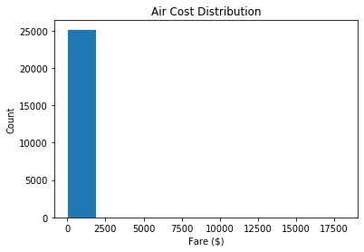

```python
plt.figure()
bins = 10
plt.hist(flight_data['MARKET_FARE'])
plt.title('Air Cost Distribution')
plt.xlabel('Fare ($)')
plt.ylabel('Count')
plt.show()
```

It's clear our flight cost data is skewed. Let's apply a logarithmic transform to the data to see the general trend.

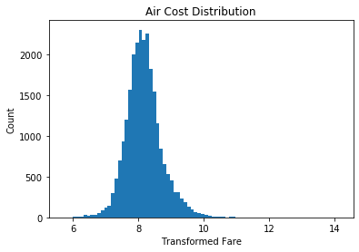

```python
plt.figure()
bins = 80
plt.hist(np.log2(flight_data["MARKET_FARE"]),bins)
plt.title('Air Cost Distribution')
plt.xlabel('Transformed Fare')
plt.ylabel('Count')
plt.show()
```

Interesting enough, we see a normal distribution in the transformed data. Since the data is skewed, let's use the median to get a sense of the center of the data.

```python
median = flight_data.median(axis=0)["MARKET_FARE"]
median
```

```
281.05125
```

Now let's use the Folium package to get a sense of the airport location distribution across the United States.

```python
airport_map = folium.Map(location=[48.5,-110],zoom_start=3.2)
for i in range(originLocation.shape[0]):
    folium.CircleMarker(
        location=[originLocation.iloc[i]['Latitude Origin'], originLocation.iloc[i]['Longitude Origin']],
        radius = 3,
        fill = True,
        fill_opacity = 0.3,
        color = '1001',#'red',
        opacity = 0.4,
        bubling_mouse_events = True,
        popup = [originLocation.iloc[i]['IATA code origin']]
    ).add_to(airport_map)
airport_map
```

Make this Notebook Trusted to load map: File -> Trust Notebook

[interactive chart not shown]

Now, let's visualize the connections from an airport. Since the number of connections between all the airports is too large to effectively visualize, let's take a look at the outgoing flights from the busiest airport in the United States: Hartsfield–Jackson Atlanta International Airport (ATL).

```python
ATL = flight_data[flight_data['IATA code origin']=='ATL']
```

```python
for i in range(ATL.shape[0]):
    folium.PolyLine([(ATL.iloc[i]['Latitude Origin'],ATL.iloc[i]['Longitude Origin']),(ATL.iloc[i]['Latitude Dest'],ATL.iloc[i]['Longitude Dest'])],
    opacity = 0.2,
    ).add_to(airport_map)
airport_map
```

Make this Notebook Trusted to load map: File -> Trust Notebook

[interactive chart not shown]

### Model: Analysis and Testing

Majority of the airport analysis will utilize [NetworkX](https://networkx.org), a Python library that is used for storing, manipulating, and analyzing graph data structures. Since we want to analyze airports in terms of their connections, it makes sense to store the flight data in a directed graph structure. A directed graph represents the data in terms of nodes and edges, where each node is an airport and edges represents flights that connect these nodes together. Since each observation in the flight data corresponds to a one-way trip, the edges need to have a direction associated with them, which is why we will use a directed graph.

The edges in a graph can contain information about certain properties between two nodes. In this project, we will encode the cost of a connecting flight in the associated edge between two nodes.

Let's construct the directional graph using NetworkX. By nature NetworkX uses a dictionary representation to store graphs. However, other storage methods exist such as adjacency lists and adjacency matrices. Each offer their own tradeoffs in terms of operational complexities and memory usage.

```python
G = nx.DiGraph()
m,n = flight_data.shape
orig = flight_data['IATA code origin']
dest = flight_data['IATA code destination']
weight = flight_data['MARKET_FARE']
for i in range(m):
    G.add_edge(orig[i],dest[i],weight=weight[i])
```

As described in the introduction, our first goal is to identify the airports that are the most popular or important. However, "importance" is a subjective term. How do we determine if an airport, or in this case a node, is important or not? In graph theory, the analysis of the "importance" of a node is known as centrality analysis. There are a couple techniques for centrality analysis that we will go through here, but there are far more out there. For further reading visit [here](https://en.wikipedia.org/wiki/Centrality).

#### Degree Centrality

```python
# get in-degree
indegreeCentrality = nx.in_degree_centrality(G)
indegreeCentrality = sorted(indegreeCentrality.items(), key=lambda x:x[1],reverse=True)
centrality = pd.DataFrame(indegreeCentrality)
centrality.columns = ['IATA code','in-degree']
# get out-degree
outdegreeCentrality = nx.out_degree_centrality(G)
outdegreeCentrality = sorted(outdegreeCentrality.items(), key=lambda x:x[1],reverse=True)
outdegreeCentrality = pd.DataFrame(outdegreeCentrality)
outdegreeCentrality.columns = ['IATA code','out-degree']
# merge results
centrality = centrality.merge(outdegreeCentrality,how='left',on='IATA code')
centrality
```

|  | IATA code | in-degree | out-degree |
| --- | --- | --- | --- |
| 0 | SEA | 0.889908 | 0.885321 |
| 1 | LAS | 0.876147 | 0.876147 |
| 2 | PHX | 0.871560 | 0.885321 |
| 3 | LAX | 0.866972 | 0.866972 |
| 4 | ORD | 0.866972 | 0.862385 |
| ... | ... | ... | ... |
| 214 | MUE | 0.004587 | 0.004587 |
| 215 | SNP | 0.004587 | 0.009174 |
| 216 | CDB | 0.004587 | 0.004587 |
| 217 | IAG | 0.004587 | 0.004587 |
| 218 | MCN | 0.000000 | 0.004587 |

219 rows × 3 columns

Let's plot these results to see if there's a correlation between in-degree and out-degree centrality measurements for airports.

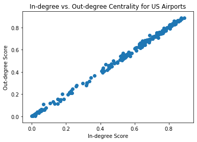

```python
plt.scatter(centrality['in-degree'],centrality['out-degree'])
plt.title("In-degree vs. Out-degree Centrality for US Airports")
plt.xlabel("In-degree Score");
plt.ylabel("Out-degree Score");
```

As one might expect there is a strong positive correlation between in-degree and out-degree centrality for airports. This means that airports that have a lot of incoming flights tend to have a lot of outgoing flights.

#### Closeness Centrality

Another way to define the importance of a node is by its ability to connect with other nodes more efficiently. In our case, closeness centrality is a measure that determines which airports are accessible by/to a large number of airports in a cost effective manner. In a similar manner to degree centrality, we can split closeness centrality into an "outbound" and an "inbound" closeness metric.

Inbound closeness will value airports that allow cheap travel *from* many other locations. Outbound closeness will value airports that have cheap travel *to* many other locations.

```python
inboundCloseness = nx.closeness_centrality(G,distance='weight')
inboundCloseness = sorted(inboundCloseness.items(), key=lambda x:x[1],reverse=True)
inboundCloseness = pd.DataFrame(inboundCloseness)
inboundCloseness.columns = ['IATA code','inbound closeness']
```

```python
outboundCloseness = nx.closeness_centrality(G.reverse(),distance='weight')
outboundCloseness = sorted(outboundCloseness.items(), key=lambda x:x[1],reverse=True)
outboundCloseness = pd.DataFrame(outboundCloseness)
outboundCloseness.columns = ['IATA code','outbound closeness']
```

```python
centrality = centrality.merge(inboundCloseness,how='inner',on='IATA code')
centrality = centrality.merge(outboundCloseness,how='inner',on='IATA code')
centrality
```

|  | IATA code | in-degree | out-degree | inbound closeness | outbound closeness |
| --- | --- | --- | --- | --- | --- |
| 0 | SEA | 0.889908 | 0.885321 | 0.003223 | 0.003217 |
| 1 | LAS | 0.876147 | 0.876147 | 0.003625 | 0.003526 |
| 2 | PHX | 0.871560 | 0.885321 | 0.003236 | 0.003265 |
| 3 | LAX | 0.866972 | 0.866972 | 0.003287 | 0.003236 |
| 4 | ORD | 0.866972 | 0.862385 | 0.003523 | 0.003619 |
| ... | ... | ... | ... | ... | ... |
| 214 | MUE | 0.004587 | 0.004587 | 0.001472 | 0.001452 |
| 215 | SNP | 0.004587 | 0.009174 | 0.000671 | 0.000775 |
| 216 | CDB | 0.004587 | 0.004587 | 0.000708 | 0.000751 |
| 217 | IAG | 0.004587 | 0.004587 | 0.002365 | 0.002359 |
| 218 | MCN | 0.000000 | 0.004587 | 0.000000 | 0.002267 |

219 rows × 5 columns

Now let's plot inbound vs. outbound closeness centrality.

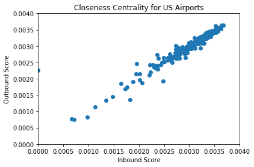

```python
plt.scatter(centrality['inbound closeness'],centrality['outbound closeness'])
plt.xlim((0,0.004))
plt.ylim((0,0.004))
plt.title("Closeness Centrality for US Airports")
plt.xlabel("Inbound Score");
plt.ylabel("Outbound Score");
```

We see that there is a positive correlation between the inbound and outbound scores. However, it is not as strong of a correlation compared to the degree centrality. This means that for the most part if an airport can get to many other locations cheaply, then many other locations can get to the airport cheaply.

#### Eigenvector Centrality

Another metric we can compute is the eigenvector centrality of the graph. This essentially ranks airports in terms of the importance of the neighbors it is connected to. Thus, if an airport is neighbors with a popular airport then its eigenvector centrality score will be high. If you would like to learn more about eigenvector centrality visit this [page](https://en.wikipedia.org/wiki/Eigenvector_centrality).

We can use NetworkX once again to calculate the values for each node.

```python
eigCent = nx.eigenvector_centrality(G)
eigCent = sorted(eigCent.items(), key=lambda x:x[1],reverse=True)
eigCent = pd.DataFrame(eigCent)
eigCent.columns = ['IATA code','eig centrality']
```

```python
centrality = centrality.merge(eigCent,how="inner",on="IATA code")
centrality
```

[output not shown]

### Part 2: Dijkstra's Shortest Path Algorithm

Now, we want to know the cheapest path given a starting and ending airport. In graph theory, this type of problem is solved via implementing a [shortest path algorithm](https://brilliant.org/wiki/shortest-path-algorithms/). These algorithms return the path between two nodes that minimizes the sum of the weights of the edges traversed. As described in the link above, there are many algorithms that perform this task. When all the edges have positive weights, the most popular algorithm is Dijkstra's algorithm (named after [Edsger W. Dijkstra](https://en.wikipedia.org/wiki/Edsger_W._Dijkstra)).

Here, I will implement Djikstra's shortest path algorithm to allow a passenger to plan out their travel in a cost-effective manner. First I will define a priority queue class to store traversed nodes with the associated cost and flight path.

#### Implementation

```python
class PriorityQueue:
    def __init__(self):
        self.q = []
    def isEmpty(self):
        if len(self.q)==0:
            return True
        else:
            return False
    def enqueue(self,obj):
        self.q.append(obj)
    def dequeue(self):
        # O(n) complexity
        assert not self.isEmpty()
        currentMin = 0
        for i in range(len(self.q)):
            x = self.q[i]
            y = self.q[currentMin]
            if x[0] < y[0]:
                currentMin = i
        Min = self.q[currentMin]
        del self.q[currentMin]
        return Min
    def reassignDistance(self,dist,adjacentNode,currentPath):
        # dist is = to dist(v)+weight(u,v)
        # O(n) complexity
        queueContents = self.q
        cp = copy.deepcopy(currentPath)
        for i in range(len(queueContents)):
            if queueContents[i][1]==adjacentNode:
                if dist<=queueContents[i][0]:
                    # reassign shorter distance if here
                    queueContents[i][0]=dist
                    # add the neighbor airport to the end of the currentPath
                    currentAirport = queueContents[i][1]
                    cp.append(currentAirport)
                    # update the current path
                    queueContents[i][2]= cp
                break
```

Now let's implement Dijkstra's algorithm. I will create a function that accepts a directed graph G and the starting airport as a string in IATA code format. The basic workings of the algorithm is [here](https://brilliant.org/wiki/dijkstras-short-path-finder/).

```python
def DijkstraShortestPath(G,starting_airport):
    # intialize priority queue
    P = PriorityQueue()
    # initalize list to store shortest path information
    Results = []
    # get all nodes from graph
    all_nodes = list(G.nodes())
    # initialize priority queue. starting airport will have a cost of zero. all other airports will have cost = Inf
    for i in all_nodes:
        if i == starting_airport:
            x = [0,i,[]]
            P.enqueue(x)
        else:
            x = [math.inf,i,[]]
            P.enqueue(x)
    # now the process is to dequeue nodes from P and find the distances to neighboring nodes.
    # nodes are deqeued from P with lowest cost as priority.
    while P.isEmpty()==False:
        # dequeue from the priority queue and get current node
        v = P.dequeue()
        currentNode = v[1]
        # if the current node does nothave any outbound flights, fully dequeue and return
        if G.out_degree(currentNode)==0:
            while P.isEmpty()==False:
                Results = Results + [v]
                v = P.dequeue()
            break
        # get all neighboring airports from graph that has currentNode (airport name) as its key
        connectedNodes = G.neighbors(currentNode)
        # iterate through the neighbor airports and compute the costs
        for i in connectedNodes:
            # reassign cost if a cheaper way to the current neighbor is found
            # there is a new minimum cost for currentAdjacentNode "u" if: currentCost(v)+pathCost(v to u)<currentCost(u)
            newCost = v[0] + G[currentNode][i]['weight']
            # feed the new cost, the neighbor node and the current path to v below
            P.reassignDistance(newCost,i,v[2])
            # P.reassignDistance updates the costs to various nodes if needed in the priority queue
        # store results
        Results = Results + [v]
    # save results
    filehandler = open("PathResults.npy", 'wb')
    pickle.dump(Results, filehandler)
```

#### Testing

First let's pick a starting airport. As an example we will use Los Angeles International Airport (LAX). By calling the Dijkstra algorithm with this starting airport, the function will save a file that contains the shortest paths from LAX to all other airports.

```python
starting_airport = 'LAX'
DijkstraShortestPath(G,starting_airport)
```

Now let's open the shortest path file and visualize the costs to other airports.

```python
file_g = open('PathResults.npy','rb')
cheapest_paths = pickle.load(file_g)
costs = []
dests = []
for i in range(len(cheapest_paths)):
    costs.append(cheapest_paths[i][0])
    dests.append(cheapest_paths[i][1])
layover_df = pd.DataFrame(costs,columns=['Costs'])
layover_df['IATA code'] = dests
layover_df = layover_df.merge(location_data,how='left',on='IATA code')
# remove rows that have infinite cost (can't get there)
infIdx = layover_df["Costs"]==math.inf
layover_df = layover_df[~infIdx]
```

Here, I will display the cheapest options from the starting airport as green, medium cost options as yellow, and expensive options as red. I will also use another plot to display the costs if we did not use Dijkstra's algorithm (if we only consider direct flights).

First, let's create the colors rangin from green to yellow to red. The Folium package takes colors input as hexidecimals, so I will use a conversion function like below.

```python
# Define the color points and corresponding colors
color_points = [0, 0.33, 0.66, 1]
colors = ['#00FF00', '#FFFF00', '#FFA500', '#FF0000']  # Green, Yellow, Orange, Red
cmap = LinearSegmentedColormap.from_list('custom_cmap', list(zip(color_points, colors)))
# Create an array with interpolated colors
N = 1001
color_array = cmap(np.linspace(0, 1, N))
```

```python
def rgba_to_hex(rgba_tuple):
    r, g, b, a = rgba_tuple
    return "#{:02X}{:02X}{:02X}".format(int(r * 255), int(g * 255), int(b * 255))

# Convert the RGBA values to hex color codes
hex_colors = [rgba_to_hex(rgba) for rgba in color_array]
```

Now let's normalize the costs and perform logarithmic transformations. This will allow us to visualize the differences in costs better.

```python
# get flight cost data for direct flights (no Dijkstra's algorithm) from starting airport
no_layover = flight_data[flight_data['IATA code origin']==starting_airport]
# initialize folium maps
new_map = folium.Map(location=[48.5,-110],zoom_start=3.2)
old_map = folium.Map(location=[48.5,-110],zoom_start=3.2)
# normalize all costs
no_layover_cost = np.array(no_layover['MARKET_FARE'])
layover_cost = np.array(layover_df['Costs'])
layover_cost = layover_cost[1:]
if min(no_layover_cost)<min(layover_cost):
    leastCost = min(no_layover_cost)
else:
    leastCost = min(layover_cost)
no_layover_cost = no_layover_cost - leastCost
layover_cost = layover_cost - leastCost
if max(no_layover_cost)>max(layover_cost):
    maxCost = max(no_layover_cost)
else:
    maxCost = max(layover_cost)
no_layover_cost = no_layover_cost/maxCost
layover_cost = layover_cost/maxCost
# since costs are skewed, perform logarithmic transformation
layover_cost = np.log(1+layover_cost)
no_layover_cost = np.log(1+no_layover_cost)
# normalize data again to match with color_array
if min(no_layover_cost)<min(layover_cost):
    leastCost = min(no_layover_cost)
else:
    leastCost = min(layover_cost)
no_layover_cost = no_layover_cost - leastCost
layover_cost = layover_cost - leastCost
if max(no_layover_cost)>max(layover_cost):
    maxCost = max(no_layover_cost)
else:
    maxCost = max(layover_cost)
no_layover_cost = no_layover_cost/maxCost
layover_cost = layover_cost/maxCost
```

Now add the cost data along with the airport location data to both Folium maps.

```python
# add to layover map
for i in range(layover_df.shape[0]):
    if i==0:
        continue
    cost = layover_cost[i-1]
    color_idx = int(math.floor(cost*(len(color_array)-1)))
    folium.CircleMarker(
        location=[layover_df.iloc[i]['Latitude Origin'], layover_df.iloc[i]['Longitude Origin']],
        radius = 2,
        fill = True,
        fill_opacity = 1,
        color = hex_colors[color_idx],
        opacity = 1,
        bubling_mouse_events = True,
        popup = [layover_df.iloc[i]['IATA code'],layover_df.iloc[i]['Costs']]
    ).add_to(new_map)
# add origin airport as big black point
folium.CircleMarker(
        location=[layover_df.iloc[0]['Latitude Origin'], layover_df.iloc[0]['Longitude Origin']],
        radius = 6,
        fill = True,
        fill_opacity = 1,
        color = 'black',
        opacity = 1,
        bubling_mouse_events = True,
        popup = [layover_df.iloc[0]['IATA code']]
    ).add_to(new_map)

# add to no layover map (direct flights)
for i in range(no_layover.shape[0]):
    cost = no_layover_cost[i]
    color_idx = int(round(cost*(len(color_array)-1)))
    folium.CircleMarker(
        location=[no_layover.iloc[i]['Latitude Dest'], no_layover.iloc[i]['Longitude Dest']],
        radius = 2,
        fill = True,
        fill_opacity = 1,
        color = hex_colors[color_idx],
        opacity = 1,
        bubling_mouse_events = True,
        popup = [no_layover.iloc[i]['IATA code destination'],no_layover.iloc[i]['MARKET_FARE']]
    ).add_to(old_map)
folium.CircleMarker(
        location=[no_layover.iloc[0]['Latitude Origin'], no_layover.iloc[0]['Longitude Origin']],
        radius = 6,
        fill = True,
        fill_opacity = 1,
        color = 'black',
        opacity = 1,
        bubling_mouse_events = True,
        popup = [no_layover.iloc[0]['IATA code origin']]
    ).add_to(old_map);
```

Finally, let's plot a map of the airports reached via Dijkstra's algorithm. As described before, green points represent cheaper flights and red points represent red points. Feel free to click on points to few the corresponding airport as well as the cost to fly there.

```python
new_map
```

Make this Notebook Trusted to load map: File -> Trust Notebook

[interactive chart not shown]

This looks pretty good! But let's compare this map to one that does not use Dikstra's algorithm. The map below gives color coded flight information that are direct flights from LAX.

```python
old_map
```

Make this Notebook Trusted to load map: File -> Trust Notebook

[interactive chart not shown]

### Interpretation

Now this does have limitations:

```
- not up-to-date information about flights and costs
- does not factor the date and time of connecting flights. Solution: I would make multiple graphs for each date and time interval, say a graph for flights every 30 minutes.
```